# GEO-notebook

## Principle Component Analysis (PCA)

Principal component analysis was conducted using the core stats package. This was done to reduce dimensionality and allow follow up analysis for differential gene expression. This also showed clusetering via the scatter plot produced for PCA, although it was clearer based on this graph compared to the heatmap that there are some data points that were not clustering as well as others.

```r
ave_X <- t(ave_X)
Xpca <- prcomp(t(ave_X), scale = TRUE)
summary(Xpca)
```

```
## Importance of components:
##                            PC1      PC2      PC3      PC4      PC5      PC6
## Standard deviation     72.1495 51.04410 45.11051 38.08761 33.21694 31.70855
## Proportion of Variance  0.1645  0.08231  0.06429  0.04583  0.03486  0.03176
## Cumulative Proportion   0.1645  0.24676  0.31105  0.35688  0.39174  0.42350
##                            PC7      PC8      PC9     PC10     PC11     PC12
## Standard deviation     27.8485 25.51179 25.01000 24.63600 23.20759 22.77523
## Proportion of Variance  0.0245  0.02056  0.01976  0.01917  0.01701  0.01639
## Cumulative Proportion   0.4480  0.46856  0.48832  0.50750  0.52451  0.54090
##                            PC13    PC14     PC15     PC16    PC17     PC18
## Standard deviation     22.44729 22.0818 21.90843 21.16166 20.4418 20.42871
## Proportion of Variance  0.01592  0.0154  0.01516  0.01415  0.0132  0.01318
## Cumulative Proportion   0.55682  0.5722  0.58738  0.60153  0.6147  0.62792
##                           PC19     PC20     PC21     PC22     PC23     PC24
## Standard deviation     20.2820 20.00601 19.83521 19.70453 19.59802 19.50208
## Proportion of Variance  0.0130  0.01264  0.01243  0.01227  0.01213  0.01202
## Cumulative Proportion   0.6409  0.65356  0.66599  0.67825  0.69039  0.70240
##                           PC25     PC26     PC27     PC28     PC29     PC30
## Standard deviation     19.1613 19.04121 18.89786 18.62942 18.46830 18.40814
## Proportion of Variance  0.0116  0.01145  0.01128  0.01096  0.01078  0.01071
## Cumulative Proportion   0.7140  0.72545  0.73674  0.74770  0.75848  0.76918
##                            PC31     PC32     PC33     PC34     PC35     PC36
## Standard deviation     18.35740 18.32389 18.21390 18.03584 17.86178 17.72840
## Proportion of Variance  0.01065  0.01061  0.01048  0.01028  0.01008  0.00993
## Cumulative Proportion   0.77983  0.79043  0.80091  0.81119  0.82127  0.83120
##                            PC37     PC38    PC39     PC40     PC41     PC42
## Standard deviation     17.63600 17.62094 17.6086 17.43933 17.34883 17.26150
## Proportion of Variance  0.00983  0.00981  0.0098  0.00961  0.00951  0.00941
## Cumulative Proportion   0.84103  0.85083  0.8606  0.87024  0.87975  0.88916
##                            PC43     PC44     PC45     PC46     PC47     PC48
## Standard deviation     17.21105 17.05562 16.98433 16.92746 16.88448 16.79492
## Proportion of Variance  0.00936  0.00919  0.00911  0.00905  0.00901  0.00891
## Cumulative Proportion   0.89852  0.90771  0.91682  0.92587  0.93488  0.94379
##                            PC49     PC50     PC51     PC52     PC53     PC54
## Standard deviation     16.71807 16.62598 16.54367 16.34413 15.66554 15.13779
## Proportion of Variance  0.00883  0.00873  0.00865  0.00844  0.00775  0.00724
## Cumulative Proportion   0.95262  0.96135  0.97000  0.97844  0.98619  0.99343
##                            PC55     PC56
## Standard deviation     14.42133 2.56e-13
## Proportion of Variance  0.00657 0.00e+00
## Cumulative Proportion   1.00000 1.00e+00
```

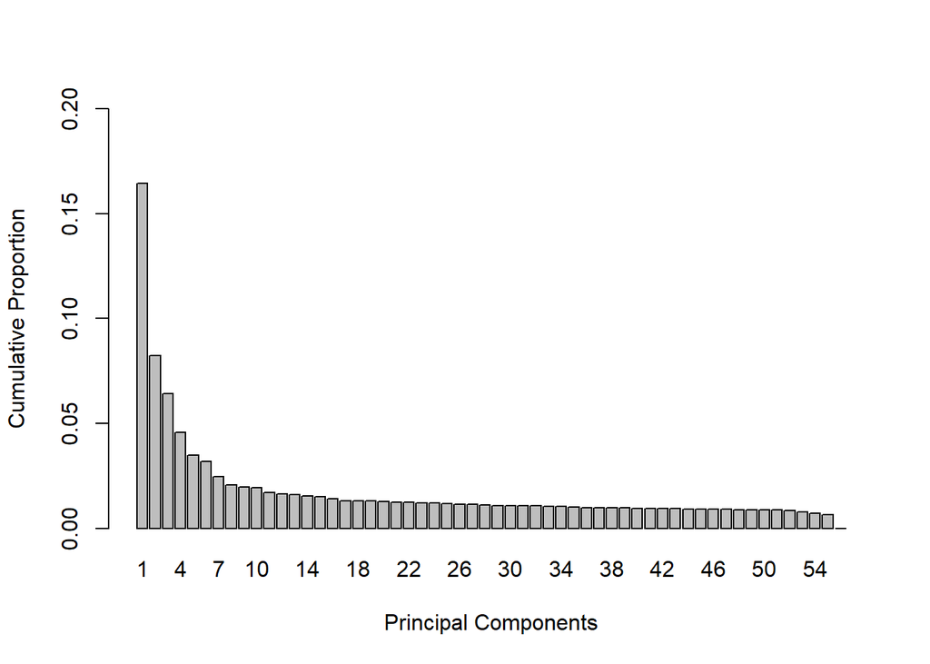

```r
barplot(Xpca$sdev^2 / sum(Xpca$sdev^2),
        ylim = c(0,0.20),
        names.arg = c(1:56),
        xlab = "Principal Components",
        ylab = "Cumulative Proportion")
```

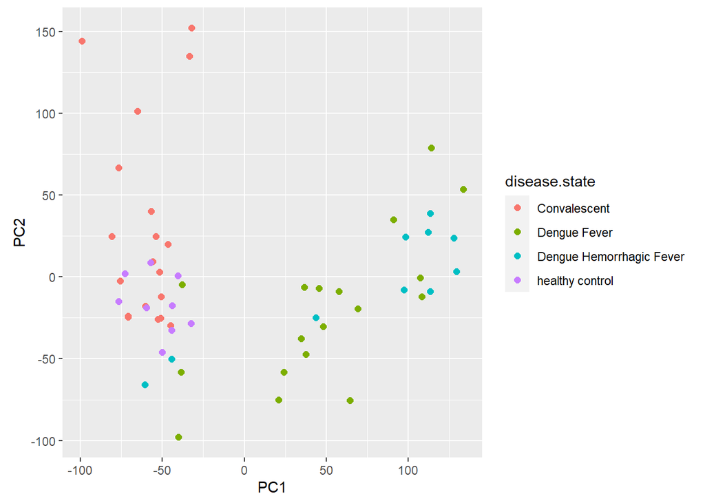

```r
PCA_scores <- as.data.frame(Xpca$x)
PCA_scores <- cbind(PCA_scores, disease_state)
PCA_scores$disease.state <- as.factor(PCA_scores$disease.state)
PCA_plot <- ggplot(data = PCA_scores, aes(x = PC1, y = PC2, color=disease.state)) +
        geom_point(size=2) +
        scale_fill_hue(l=40) +
        coord_fixed(ratio = 1, xlim = range(PCA_scores$PC1), ylim = range(PCA_scores$PC2))
PCA_plot
```

## Differential Expression Analysis via Volcano Plot

```
##        Convalescent Dengue_Fever Dengue_Hemorrhagic_Fever Healthy_Control
## DDR1       2.386595     2.295331                 2.247577        2.522704
## RFC2       2.777086     2.959374                 2.949941        2.787019
## HSPA6      3.297300     3.287822                 3.172985        3.393106
## PAX8       1.871144     1.820033                 1.831526        1.813254
## GUCA1A     1.780432     1.768136                 1.770653        1.769120
## UBA7       3.167743     3.198212                 3.180943        3.174498
```

```
##             logFC  AveExpr         t      P.Value    adj.P.Val        B
## KCTD14  0.9454432 2.238768  14.25899 3.110586e-20 9.846248e-16 35.31622
## FAM72A  0.6192452 2.786199  12.89955 2.300429e-18 2.614297e-14 31.23690
## BAK1    0.3858206 2.710259  12.87674 2.477693e-18 2.614297e-14 31.16623
## CD38    0.7755474 3.112704  12.52674 7.803542e-18 6.175333e-14 30.07280
## UBE2S   0.3984425 3.056041  12.19693 2.333873e-17 1.477529e-13 29.02660
## CAMK1D -0.3514254 3.015747 -11.65543 1.453239e-16 7.666802e-13 27.27594
## BRCA2   0.5497897 2.042844  11.28258 5.231350e-16 2.069874e-12 26.04694
## CASP7   0.2833491 3.090488  11.28248 5.233155e-16 2.069874e-12 26.04661
## CEP55   1.0471435 2.519249  11.24855 5.885154e-16 2.069874e-12 25.93383
## T81422  0.7923026 2.645775  11.12671 8.982322e-16 2.803389e-12 25.52757
```

```
##
##    -1     0     1
##  3613 24429  3612
```

```
## Warning: Removed 2 rows containing missing values (geom_text_repel).
```

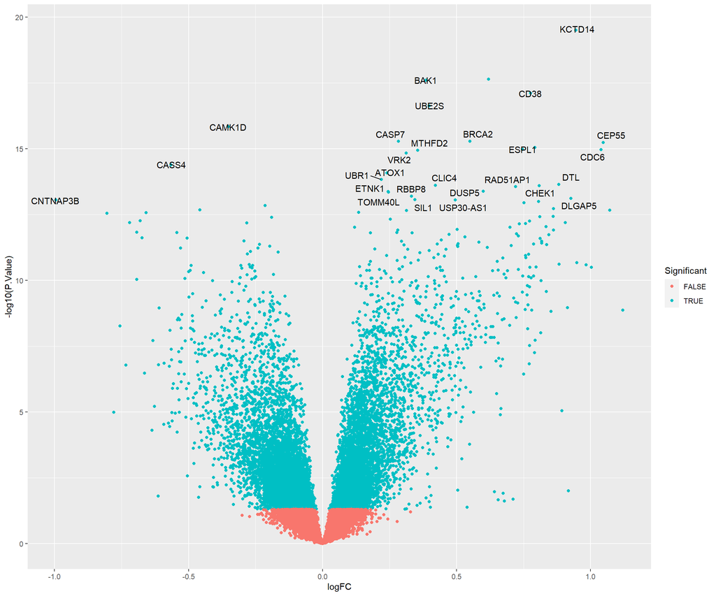

The data used was a comparison between Dengue haemorrhagic fever and healthy controls. Those genes that showed significant adjusted p-values were separated and then passed onto the next of gene set enrichment analysis, where these genes would be grouped using databases of networks and reactomes and determine which pathways are most likely affected.